# Ford GoBike Data Exploration

## Preliminary Wrangling

This document explores a dataset containing duration and features for approximately 300,000 trip records from January 2020.

```python
# import all packages and set plots to be embedded inline
import numpy as np
import pandas as pd
import zipfile
import time
import matplotlib.pyplot as plt
import seaborn as sb

%matplotlib inline
```

```python
# extract the .csv file from the .zip file
with zipfile.ZipFile('202001-baywheels-tripdata.csv.zip', 'r') as myzip:
    myzip.extractall()
```

```python
# load the dataset into a pandas dataframe
baywheels = pd.read_csv('202001-baywheels-tripdata.csv')
```

```python
# high-level overview of data shape and composition
print(baywheels.shape)
print(baywheels.dtypes)
print(baywheels.head(10))
```

```
(295854, 14)
duration_sec                 int64
start_time                  object
end_time                    object
start_station_id           float64
start_station_name          object
start_station_latitude     float64
start_station_longitude    float64
end_station_id             float64
end_station_name            object
end_station_latitude       float64
end_station_longitude      float64
bike_id                      int64
user_type                   object
rental_access_method        object
dtype: object
   duration_sec                start_time                  end_time  \
0         83118  2020-01-31 15:23:47.7330  2020-02-01 14:29:06.2630
1         68239  2020-01-31 15:40:31.6160  2020-02-01 10:37:51.0000
2         55407  2020-01-31 17:48:16.6350  2020-02-01 09:11:44.3170
3         54929  2020-01-31 17:53:03.4130  2020-02-01 09:08:32.6340
4         55700  2020-01-31 17:12:33.4600  2020-02-01 08:40:53.6460
5         11333  2020-01-31 22:48:22.6390  2020-02-01 01:57:15.7160
6         11341  2020-01-31 22:48:12.9890  2020-02-01 01:57:14.1650
7          4038  2020-01-31 23:32:03.9070  2020-02-01 00:39:22.0210
8          4059  2020-01-31 23:31:01.1610  2020-02-01 00:38:40.8570
9          1980  2020-01-31 23:49:09.2300  2020-02-01 00:22:09.7540

   start_station_id             start_station_name  start_station_latitude  \
0             400.0  Buchanan St at North Point St               37.804272
1              99.0           Folsom St at 15th St               37.767037
2             197.0    El Embarcadero at Grand Ave               37.808848
3             197.0    El Embarcadero at Grand Ave               37.808848
4              12.0    Pier 1/2 at The Embarcadero               37.796389
5              60.0           8th St at Ringold St               37.774520
6              60.0           8th St at Ringold St               37.774520
7             450.0       Funston Ave at Irving St               37.763934
8             450.0       Funston Ave at Irving St               37.763934
9             238.0   MLK Jr Way at University Ave               37.871719

```

[output cut: 20 more lines]

```
7             37.763934            -122.470651     1589    Customer
8             37.763934            -122.470651    12884    Customer
9             37.807813            -122.264496    10464    Customer

  rental_access_method
0                  NaN
1                  NaN
2                  NaN
3                  NaN
4                  NaN
5                  NaN
6                  NaN
7                  NaN
8                  NaN
9                  NaN
```

```python
#make a copy before cleaning the data
baywheels_clean = baywheels.copy()
```

```python
#drop columns that won't be used in the analysis
baywheels_clean = baywheels_clean.drop(['start_station_latitude', 'start_station_longitude', 'end_station_latitude', 'end_station_longitude', 'start_station_id', 'end_station_id', 'bike_id'], axis=1)
```

```python
#test
baywheels_clean.head()
```

|  | duration_sec | start_time | end_time | start_station_name | end_station_name | user_type | rental_access_method |
| --- | --- | --- | --- | --- | --- | --- | --- |
| 0 | 83118 | 2020-01-31 15:23:47.7330 | 2020-02-01 14:29:06.2630 | Buchanan St at North Point St | Buchanan St at North Point St | Customer | NaN |
| 1 | 68239 | 2020-01-31 15:40:31.6160 | 2020-02-01 10:37:51.0000 | Folsom St at 15th St | Folsom St at 15th St | Subscriber | NaN |
| 2 | 55407 | 2020-01-31 17:48:16.6350 | 2020-02-01 09:11:44.3170 | El Embarcadero at Grand Ave | El Embarcadero at Grand Ave | Customer | NaN |
| 3 | 54929 | 2020-01-31 17:53:03.4130 | 2020-02-01 09:08:32.6340 | El Embarcadero at Grand Ave | El Embarcadero at Grand Ave | Customer | NaN |
| 4 | 55700 | 2020-01-31 17:12:33.4600 | 2020-02-01 08:40:53.6460 | Pier 1/2 at The Embarcadero | Lombard St at Columbus Ave | Customer | NaN |

```python
#add day of the week column
baywheels_clean['day_of_week'] = pd.to_datetime(baywheels_clean['start_time']).dt.weekday_name
```

```python
#test
baywheels_clean.head()
```

|  | duration_sec | start_time | end_time | start_station_name | end_station_name | user_type | rental_access_method | day_of_week |
| --- | --- | --- | --- | --- | --- | --- | --- | --- |
| 0 | 83118 | 2020-01-31 15:23:47.7330 | 2020-02-01 14:29:06.2630 | Buchanan St at North Point St | Buchanan St at North Point St | Customer | NaN | Friday |
| 1 | 68239 | 2020-01-31 15:40:31.6160 | 2020-02-01 10:37:51.0000 | Folsom St at 15th St | Folsom St at 15th St | Subscriber | NaN | Friday |
| 2 | 55407 | 2020-01-31 17:48:16.6350 | 2020-02-01 09:11:44.3170 | El Embarcadero at Grand Ave | El Embarcadero at Grand Ave | Customer | NaN | Friday |
| 3 | 54929 | 2020-01-31 17:53:03.4130 | 2020-02-01 09:08:32.6340 | El Embarcadero at Grand Ave | El Embarcadero at Grand Ave | Customer | NaN | Friday |
| 4 | 55700 | 2020-01-31 17:12:33.4600 | 2020-02-01 08:40:53.6460 | Pier 1/2 at The Embarcadero | Lombard St at Columbus Ave | Customer | NaN | Friday |

```python
# high-level overview of data shape and composition
print(baywheels_clean.shape)
print(baywheels_clean.dtypes)
```

```
(295854, 8)
duration_sec             int64
start_time              object
end_time                object
start_station_name      object
end_station_name        object
user_type               object
rental_access_method    object
day_of_week             object
dtype: object
```

### What is the structure of your dataset?

There are 295,854 records in the dataset with 8 features: duration, start time, end time, start station name, end station name, user type, rental access method, and day of the week. Duration is the only quantitative variable, the rest are qualitative variables.

user type: subscriber, customer  
rental access method: app, clipper

### What is/are the main feature(s) of interest in your dataset?

I'm most interested in figuring out what features are best for predicting the trip duration for the records in the dataset.

### What features in the dataset do you think will help support your investigation into your feature(s) of interest?

I expect that user type will have the strongest effect on each trip's duration: subscribers' trips will be longer. I also think that the other features: rental access method, day of the week, start station, end station will have effects on the duration.

## Univariate Exploration

I'll start by looking at the distribution of the main variable of interest: duration.

```python
#check descriptive statistics for duration
baywheels_clean['duration_sec'].describe()
```

```
count    295854.000000
mean        780.473193
std        2037.786317
min          60.000000
25%         369.000000
50%         588.000000
75%         912.000000
max      811077.000000
Name: duration_sec, dtype: float64
```

```python
#811077 seconds is 225 hours, that looks like a faulty record
#check everything more than 24 hours (=86400)
baywheels_clean[baywheels_clean["duration_sec"] > 86400]
```

|  | duration_sec | start_time | end_time | start_station_name | end_station_name | user_type | rental_access_method | day_of_week |
| --- | --- | --- | --- | --- | --- | --- | --- | --- |
| 121168 | 811077 | 2020-01-09 16:23:21 | 2020-01-19 01:41:19 | NaN | NaN | Subscriber | clipper | Thursday |

```python
#drop this presumably faulty record
baywheels_clean = baywheels_clean[baywheels_clean.duration_sec != 811077]
```

```python
#test
baywheels_clean[baywheels_clean["duration_sec"] > 86400]
```

|  | duration_sec | start_time | end_time | start_station_name | end_station_name | user_type | rental_access_method | day_of_week |
| --- | --- | --- | --- | --- | --- | --- | --- | --- |

```python
# check data shape
print(baywheels_clean.shape)
```

```
(295853, 8)
```

```python
baywheels_clean['duration_sec'].describe()
```

```
count    295853.000000
mean        777.734344
std        1390.428974
min          60.000000
25%         369.000000
50%         588.000000
75%         912.000000
max       86221.000000
Name: duration_sec, dtype: float64
```

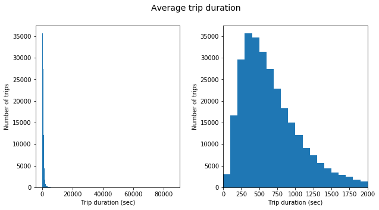

```python
# start with a standard-scaled plot, then zoom into part where most of the data points lie
fig = plt.figure(figsize = [10, 5])
st = fig.suptitle("Average trip duration", fontsize = 14)
plt.subplots_adjust(wspace = 0.3)

# histogram on left: full data
#fig.suptitle("Title centered above all subplots", fontsize=14)
plt.subplot(1, 2, 1)
bin_edges = np.arange(0, baywheels_clean['duration_sec'].max()+ 100, 100)
plt.hist(data = baywheels_clean, x = 'duration_sec', bins = bin_edges);
plt.xlabel('Trip duration (sec)');
plt.ylabel('Number of trips');

# histogram on right: focus in on bulk of data < 3000
plt.subplot(1, 2, 2)
bin_edges = np.arange(0, 2000 + 100, 100)
plt.hist(data = baywheels_clean, x = 'duration_sec', bins = bin_edges);
plt.xlim(0, 2000);
plt.xlabel('Trip duration (sec)');
plt.ylabel('Number of trips');
```

When we limit the axis to 2000 seconds (33 minutes) and use bins of 100 seconds, we get the clear picture that the typical ride length lies between a 300- and 700-second range (5-12 minutes).

```python
#check outliers
baywheels_clean[baywheels_clean["duration_sec"] > 3000].shape[0]
```

```
4527
```

With minimum duration value being 60 seconds and maximum duration value being 86221 seconds (almost 24 hours), duration has a long-tailed distribution, with a lot of trips on the low duration end, and few on the high duration end. Of the 295,853 records in the dataset, 4527 records are above 3,000 seconds in duration, which is still a lot, so I wouldn't rather remove them from the dataset. Next, I'll plot the duration values on a log-scale to understand the distributions better.

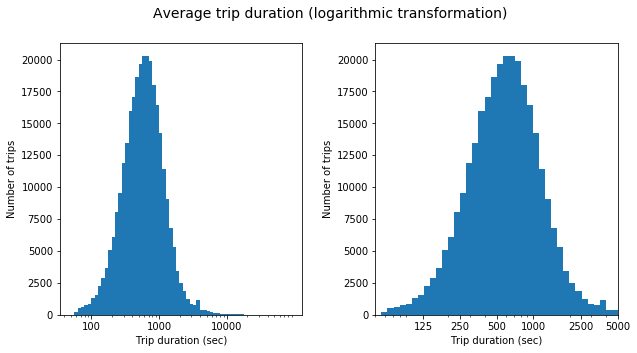

```python
# there's a long tail in the distribution, so let's additionally put it on a log scale
fig = plt.figure(figsize = [10, 5])
st = fig.suptitle("Average trip duration (logarithmic transformation)", fontsize = 14)
plt.subplots_adjust(wspace = 0.3)

# histogram on left: full data
plt.subplot(1, 2, 1)
log_binsize = 0.05
bins = 10 ** np.arange(1.7, np.log10(baywheels_clean['duration_sec'].max())+log_binsize, log_binsize)
ticks = [100, 1000, 10000]
labels = ['{}'.format(val) for val in ticks]
plt.hist(data = baywheels_clean, x = 'duration_sec', bins = bins)
plt.xscale('log')
plt.xticks(ticks, labels);
plt.xlabel('Trip duration (sec)');
plt.ylabel('Number of trips');


# histogram on right: focus in on bulk of data < 5000
plt.subplot(1, 2, 2)
log_binsize = 0.05
bins = 10 ** np.arange(1.7, np.log10(baywheels_clean['duration_sec'].max())+log_binsize, log_binsize)
ticks = [0, 125, 250, 500, 1000, 2500, 5000]
labels = ['{}'.format(val) for val in ticks]
plt.hist(data = baywheels_clean, x = 'duration_sec', bins = bins)
plt.xscale('log')
plt.xticks(ticks, labels);
plt.xlabel('Trip duration (sec)')
plt.ylabel('Number of trips');
plt.xlim(50, 5000);
```

```python
#figuring out bins and xticks
np.log10(baywheels_clean['duration_sec'].describe())
```

```
count    5.471076
mean     2.890831
std      3.143149
min      1.778151
25%      2.567026
50%      2.769377
75%      2.959995
max      4.935613
Name: duration_sec, dtype: float64
```

When plotted on a log-scale, the duration distribution looks quite unimodal, with a peak between 300 and 700 seconds. This support our observation from zooming into the direct duration data from the earlier. Next up, let's move to the other variables in the dataset: user type, rental access method, and day of the week.

```python
# convert user type and rental access method into ordered categorical types
ordinal_var_dict = {'user_type': ['Subscriber','Customer'],
                    'rental_access_method': ['app', 'clipper'],
                    'day_of_week': ['Monday', 'Tuesday', 'Wednesday', 'Thursday', 'Friday', 'Saturday', 'Sunday']}

for var in ordinal_var_dict:
    ordered_var = pd.api.types.CategoricalDtype(ordered = True,
                                                categories = ordinal_var_dict[var])
    baywheels_clean[var] = baywheels_clean[var].astype(ordered_var)
```

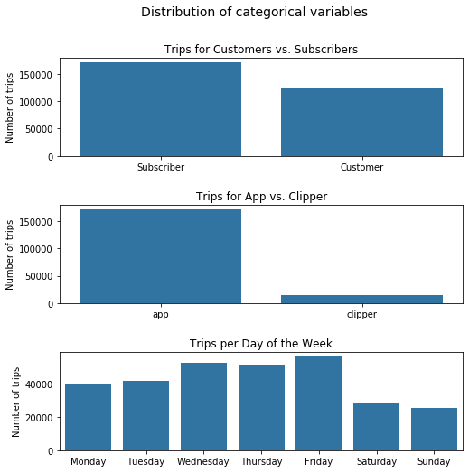

```python
# let's plot all the three together to get an idea of each ordinal variable's distribution.

fig, ax = plt.subplots(nrows=3, figsize = [8,8])
st = fig.suptitle("Distribution of categorical variables", fontsize = 14)
plt.subplots_adjust(hspace = 0.5)

default_color = sb.color_palette()[0]
sb.countplot(data = baywheels_clean, x = 'user_type', color = default_color, ax = ax[0])
ax[0].set(xlabel = None, ylabel='Number of trips', title = 'Trips for Customers vs. Subscribers')
sb.countplot(data = baywheels_clean, x = 'rental_access_method', color = default_color, ax = ax[1])
ax[1].set(xlabel = None, ylabel='Number of trips', title = 'Trips for App vs. Clipper')
sb.countplot(data = baywheels_clean, x = 'day_of_week', color = default_color, ax = ax[2])
ax[2].set(xlabel = None, ylabel='Number of trips', title = 'Trips per Day of the Week')

plt.show()
```

The majority of trips in the dataset are made by subscribers and the highly preferred rental access method is app. Most of trips take place on weekdays rather than weekends, with Mondays and Tuesdays being somewhat less popular.

I'll now look at the start and end station in the data to see if any of them hold interesting properties.

```python
baywheels_clean['start_station_name'].describe()
```

```
count                   146866
unique                     430
top       Market St at 10th St
freq                      2753
Name: start_station_name, dtype: object
```

```python
baywheels_clean['end_station_name'].describe()
```

```
count                                             146511
unique                                               429
top       San Francisco Caltrain (Townsend St at 4th St)
freq                                                5023
Name: end_station_name, dtype: object
```

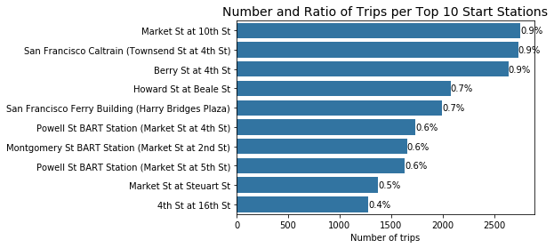

```python
#create a horizontal bar chart with trip counts and relative trip frequencies for the top 10 most popular start stations
default_color = sb.color_palette()[0]
type_counts = baywheels_clean['start_station_name'].value_counts().head(10)
type_order = baywheels_clean['start_station_name'].value_counts().head(10).index
sb.countplot(data = baywheels_clean, y = 'start_station_name', color = default_color, order = type_order)
n_baywheels = baywheels_clean.shape[0]

for i in range(type_counts.shape[0]):
    count = type_counts[i]
    pct_string = '{:0.1f}%'.format(100*count/n_baywheels)
    plt.text(count+1, i, pct_string, va = 'center');

plt.title('Number and Ratio of Trips per Top 10 Start Stations', fontsize = 14);
plt.ylabel('')
plt.xlabel('Number of trips');
```

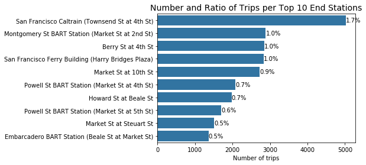

```python
#create a horizontal bar chart with trip counts and relative trip frequencies for the top 10 most popular end stations
default_color = sb.color_palette()[0]
type_counts = baywheels_clean['end_station_name'].value_counts().head(10)
type_order = baywheels_clean['end_station_name'].value_counts().head(10).index
sb.countplot(data = baywheels_clean, y = 'end_station_name', color = default_color, order = type_order)
n_baywheels = baywheels_clean.shape[0]

for i in range(type_counts.shape[0]):
    count = type_counts[i]
    pct_string = '{:0.1f}%'.format(100*count/n_baywheels)
    plt.text(count+1, i, pct_string, va = 'center');

plt.title('Number and Ratio of Trips per Top 10 End Stations', fontsize = 14);
plt.ylabel('');
plt.xlabel('Number of trips');
```

There are 430 unique stations in the dataset, and the bar charts above show trip count and relative usage frequencies for the top 10 start and end stations. San Francisco Caltain stands out in these bar charts: it's top 1 end station with a considerable proportional overweight compared to the second most popular end station and the other stations in the dataset. It's also the second most popular start station.

### Discuss the distribution(s) of your variable(s) of interest. Were there any unusual points? Did you need to perform any transformations?

The duration variable took on a large range of values, so I looked at the data changing axis limits and using a log transform. Both zooming-in and the log trasformation revealed the typical ride length between a 300- and 700-second range (5-12 minutes).

### Of the features you investigated, were there any unusual distributions? Did you perform any operations on the data to tidy, adjust, or change the form of the data? If so, why did you do this?

Duration variable proved to have an extremely long tail, with the majority of data lying before 3,000 seconds (50 minutes). The outliers are 4527 records above 3,000 seconds (50 minutes) and below 86,222 seconds (23.95 hours) in duration, which I decided to keep because they make sense from the practical standpoint. The only outlier I removed from the dataset is a 811,077-second (225-hour) trip, which made no practical sense.

## Bivariate Exploration

Duration is the only quantitative variable in the dataset. It means that we don't have an option for using scatterplots in our bivariate exploration. Thus, we'll be using violin and box plots for quantitative vs. qualitative variables and clustered bar charts for qualitative vs. qualitative variables. To begin with, let's take a look at trip duration per categorical variables.

```python
numeric_vars = ['duration_sec']
categoric_vars = ['user_type', 'rental_access_method', 'day_of_week']
```

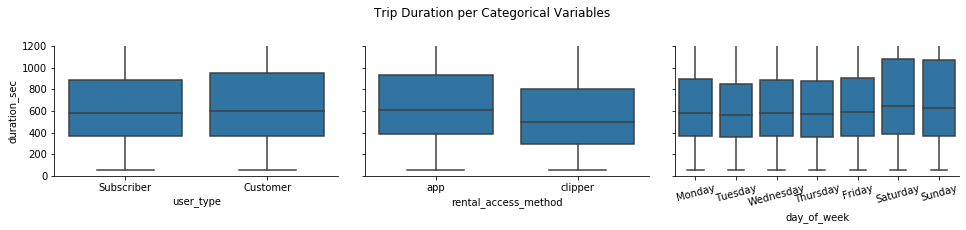

```python
# plot duration against categorical features as faceted box plots
def boxgrid(x, y, **kwargs):
    default_color = sb.color_palette()[0]
    sb.boxplot(x, y, color = default_color)

plt.figure(figsize = [1000, 1000])

g = sb.PairGrid(data = baywheels_clean, y_vars = ['duration_sec'], x_vars = categoric_vars,
                height = 3, aspect = 1.5);
g.map(boxgrid);
plt.subplots_adjust(top=0.8);
g.fig.suptitle('Trip Duration per Categorical Variables')
plt.xticks(rotation = 15);
plt.ylim(0, 1200); # zoom into part where most of the data points lie
plt.show();
```

It appears that customers and app users tend to take longer rides. Interestingly, rides on weekends tend to be considerably longer compared to weekdays.

Next, let's look at relationships between the three categorical features:  
(1) number of trips per user type and rental access method  
(2) number of trips per day of the week and rental access method  
(3) number of trips per day of the week and user type

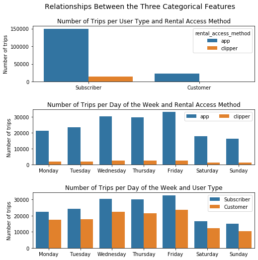

```python
# look at the relationships between the three categorical features
fig = plt.figure(figsize = [8, 8])
st = fig.suptitle("Relationships Between the Three Categorical Features", fontsize = 14)
plt.subplots_adjust(top = 0.9, hspace = 0.5)

# subplot 1: color vs cut
ax1 = plt.subplot(3, 1, 1)
sb.countplot(data = baywheels_clean, x = 'user_type', hue = 'rental_access_method')
ax1.set(xlabel = None, ylabel = "Number of trips", title = 'Number of Trips per User Type and Rental Access Method')

# subplot 2: clarity vs. cut
ax2 = plt.subplot(3, 1, 2)
sb.countplot(data = baywheels_clean, x = 'day_of_week', hue = 'rental_access_method')
ax2.set(xlabel = None, ylabel = "Number of trips", title = 'Number of Trips per Day of the Week and Rental Access Method')
ax2.legend(ncol = 2) # re-arrange legend to reduce overlapping

# subplot 3: clarity vs. color, use different color palette
ax3 = plt.subplot(3, 1, 3)
sb.countplot(data = baywheels_clean, x = 'day_of_week', hue = 'user_type')
ax3.set(xlabel = None, ylabel = "Number of trips", title = 'Number of Trips per Day of the Week and User Type')
ax3.legend(ncol = 1)# re-arrange legend to remove overlapping

plt.show()
```

## Multivariate Exploration

To start off with, I want to look at the average trip duration per day of the week across user type and rental access method.

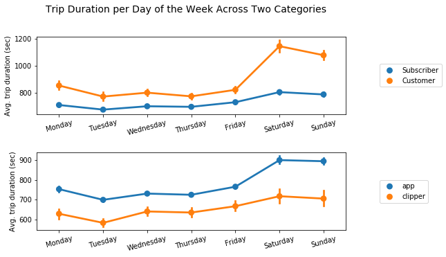

```python
#visualize average trip duration per day of the week across user type and rental access method in a point plot

fig = plt.figure(figsize = [8, 8])
st = fig.suptitle("Trip Duration per Day of the Week Across Two Categories", fontsize = 14)
plt.subplots_adjust(top = 0.9, hspace = 0.5)

# subplot 1:
ax1 = plt.subplot(3, 1, 1)
sb.pointplot(data = baywheels_clean, x = 'day_of_week', y = 'duration_sec', hue = 'user_type')
ax1.set(xlabel = None, ylabel = "Avg. trip duration (sec)")
plt.xticks(rotation = 15)
plt.legend(loc='center left', bbox_to_anchor=(1.1, 0.5), ncol=1)# re-arrange legend to remove overlapping

# subplot 2:
ax2 = plt.subplot(3, 1, 2)
sb.pointplot(data = baywheels_clean, x = 'day_of_week', y = 'duration_sec', hue = 'rental_access_method')
ax2.set(xlabel = None, ylabel = "Avg. trip duration (sec)")
plt.xticks(rotation = 15)
plt.legend(loc='center left', bbox_to_anchor=(1.1, 0.5), ncol=1)# re-arrange legend to remove overlapping
plt.show()
```

Supporting the insight from the earlier, customers tend to take longer rides, especially on weekends. App users' rides are longer than those of clipper users, which is natural: clipper users are more likely to be using Ford GoBike as public trasport, so their trip are shorter. If we look at the same relationships visualized as box plots, we'll see the trend even more clearly: the third quartile as for weekends is proportionally considerable higher for the weekends. Moreover, weekends have a long tail of outliers, stretching beyond the limited area, where most of the data points lie.

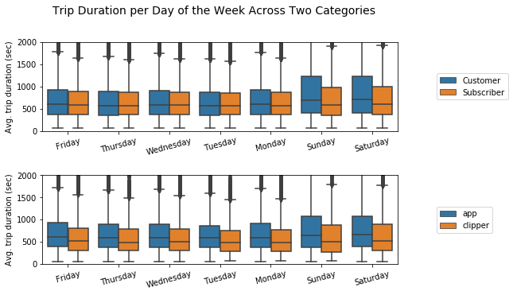

```python
fig = plt.figure(figsize = [8, 8])
st = fig.suptitle("Trip Duration per Day of the Week Across Two Categories", fontsize = 14)
plt.subplots_adjust(top = 0.9, hspace = 0.5)

# subplot 1:
ax1 = plt.subplot(3, 1, 1)
sb.boxplot(data = baywheels_clean, x = 'day_of_week', y = 'duration_sec', hue = 'user_type')
ax1.set(xlabel = None, ylabel = "Avg. trip duration (sec)")
plt.xticks(rotation = 15)
plt.ylim(0, 2000);
plt.legend(loc='center left', bbox_to_anchor=(1.1, 0.5), ncol=1)# re-arrange legend to remove overlapping

# subplot 2:
ax2 = plt.subplot(3, 1, 2)
sb.boxplot(data = baywheels_clean, x = 'day_of_week', y = 'duration_sec', hue = 'rental_access_method')
ax2.set(xlabel = None, ylabel = "Avg. trip duration (sec)")
plt.xticks(rotation = 15)
plt.ylim(0, 2000);
plt.legend(loc='center left', bbox_to_anchor=(1.1, 0.5), ncol=1)# re-arrange legend to remove overlapping
plt.show()
```

Finally, I'm interested in looking into trip duration for top five start stations across the categorical features.

```python
#create a dataframe for top 5 start stations
top_5_start_stations = baywheels_clean['start_station_name'].value_counts().index[:5]
top_stations = baywheels_clean.loc[baywheels_clean['start_station_name'].isin(top_5_start_stations)]
top_stations['start_station_name'].value_counts()
```

```
Market St at 10th St                                  2753
San Francisco Caltrain (Townsend St at 4th St)        2734
Berry St at 4th St                                    2638
Howard St at Beale St                                 2076
San Francisco Ferry Building (Harry Bridges Plaza)    1998
Name: start_station_name, dtype: int64
```

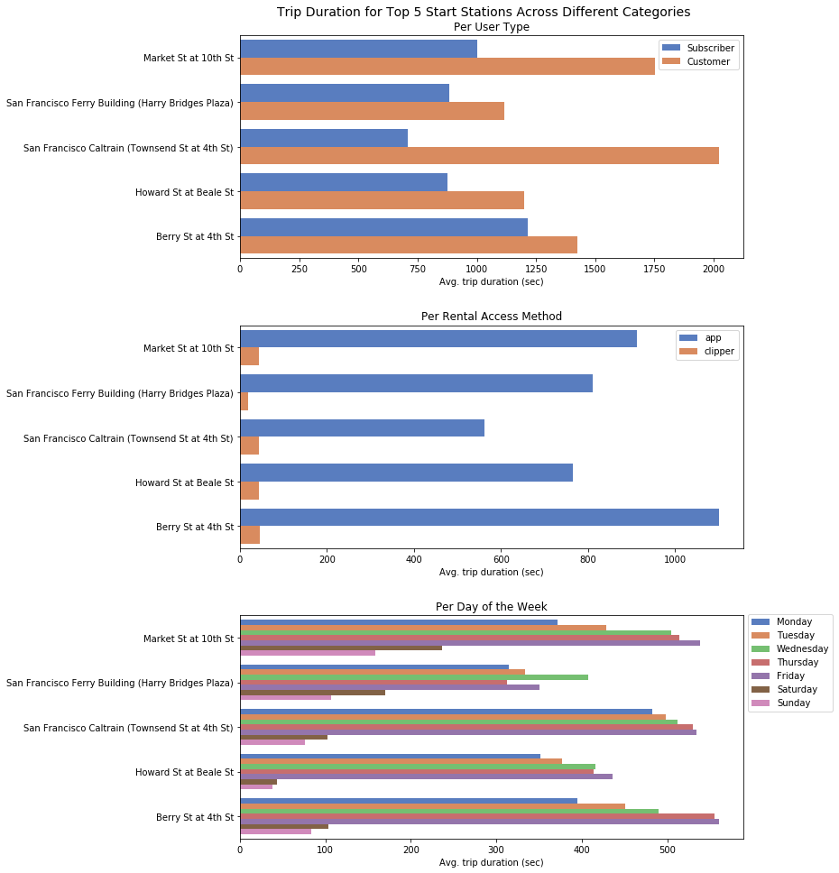

```python
#visualize the data in subsets of bar charts
fig = plt.figure(figsize = [10, 15])
st = fig.suptitle("Trip Duration for Top 5 Start Stations Across Different Categories", fontsize = 14)
plt.subplots_adjust(top = 0.95, hspace = 0.3)

# subplot 1: color vs cut
ax1 = plt.subplot(3, 1, 1)
sb.countplot(data = top_stations, y = 'start_station_name', hue = 'user_type', palette = 'muted')
ax1.set(xlabel = "Avg. trip duration (sec)", ylabel = None, title = "Per User Type")
ax1.legend().set_title('')

# subplot 2: clarity vs. cut
ax2 = plt.subplot(3, 1, 2)
sb.countplot(data = top_stations, y = 'start_station_name', hue = 'rental_access_method', palette = 'muted')
ax2.set(xlabel = "Avg. trip duration (sec)", ylabel = None, title = "Per Rental Access Method")
ax2.legend().set_title('')

# subplot 3: clarity vs. color, use different color palette
ax3 = plt.subplot(3, 1, 3)
g = sb.countplot(data = top_stations, y = 'start_station_name', hue = 'day_of_week', palette = 'muted')
ax3.set(xlabel = "Avg. trip duration (sec)", ylabel = None, title = "Per Day of the Week")
#ax3.legend(loc = 4, bbox_to_anchor=(1.25, 0.5), ncol=1) # re-arrange legend to remove overlapping
ax3.legend().set_title('')
g.legend(loc = 3, bbox_to_anchor=(1, 0.55), ncol=1)

plt.show()
```